# Лабораторийн ажил 3

## Numpy болон Pandas

Уг заавар нь numpy болон pandas-н сангийн модулиудын хэрэглээний жишээнүүдийг агуулна. Дараах зааварчилгааг алхам алхмаар анхааралтай уншиж, кодыг гүйцэтгэхийн тулд SHIFT+ENTER товчны хослолыг дарна уу.

## 3.1 Numpy

Numpy нь numerical Python гэсэн үг бөгөөд тоон тооцооллыг дэмждэг Python сангийн багц юм. numpy дахь үндсэн өгөгдлийн бүтэц нь ndarray гэж нэрлэгддэг олон хэмжээст массив объект юм. Numpy нь ndarray-ийн элементүүдийг үр дүнтэй удирдах боломжтой функцүүдээр хангадаг.

### 3.1.1 ndarray үүсгэх

ndarray нь дараах жишээнд харуулсан шиг tuple обьект эсвэл жагсаалтаас (list) үүсгэгдэж болно. Жагсаалтын (list) обьектуудаас, түүнчлэн tuple-с нэг хэмжээст эсвэл олон хэмжээст массив үүсгэх боломжтой.

```python
import numpy as np

oneDim = np.array([1.0,2,3,4,5])   # a 1-dimensional array (vector)
print(oneDim)
print("#Dimensions =", oneDim.ndim)
print("Dimension =", oneDim.shape)
print("Size =", oneDim.size)
print("Array type =", oneDim.dtype, '\n')

twoDim = np.array([[1,2],[3,4],[5,6],[7,8]])  # a two-dimensional array (matrix)
print(twoDim)
print("#Dimensions =", twoDim.ndim)
print("Dimension =", twoDim.shape)
print("Size =", twoDim.size)
print("Array type =", twoDim.dtype, '\n')

arrFromTuple = np.array([(1,'a',3.0),(2,'b',3.5)])  # create ndarray from tuple
print(arrFromTuple)
print("#Dimensions =", arrFromTuple.ndim)
print("Dimension =", arrFromTuple.shape)
print("Size =", arrFromTuple.size)
```

Үүнээс гадна ndarray үүсгэх боломжтой функцүүд байдаг.

```python
print('Array of random numbers from a uniform distribution')
print(np.random.rand(5))      # random numbers from a uniform distribution between [0,1]

print('\nArray of random numbers from a normal distribution')
print(np.random.randn(5))     # random numbers from a normal distribution

print('\nArray of integers between -10 and 10, with step size of 2')
print(np.arange(-10,10,2))    # similar to range, but returns ndarray instead of list

print('\n2-dimensional array of integers from 0 to 11')
print(np.arange(12).reshape(3,4))  # reshape to a matrix

print('\nArray of values between 0 and 1, split into 10 equally spaced values')
print(np.linspace(0,1,10))    # split interval [0,1] into 10 equally separated values

print('\nArray of values from 10^-3 to 10^3')
print(np.logspace(-3,3,7))    # create ndarray with values from 10^-3 to 10^3
```

```python
print('A 2 x 3 matrix of zeros')
print(np.zeros((2,3)))        # a matrix of zeros

print('\nA 3 x 2 matrix of ones')
print(np.ones((3,2)))         # a matrix of ones

print('\nA 3 x 3 identity matrix')
print(np.eye(3))              # a 3 x 3 identity matrix
```

## 3.1.2 Операторууд

ndarray-ийн элемент бүр дээр нэмэх, үржүүлэх зэрэг стандарт операторуудыг ашиглаж болно.

```python
x = np.array([1,2,3,4,5])

print('x =', x)
print('x + 1 =', x + 1)      # addition
print('x - 1 =', x - 1)      # subtraction
print('x * 2 =', x * 2)      # multiplication
print('x // 2 =', x // 2)     # integer division
print('x ** 2 =', x ** 2)     # square
print('x % 2 =', x % 2)      # modulo
print('1 / x =', 1 / x)      # division
```

```python
x = np.array([2,4,6,8,10])
y = np.array([1,2,3,4,5])

print('x =', x)
print('y =', y)
print('x + y =', x + y)      # element-wise addition
print('x - y =', x - y)      # element-wise subtraction
print('x * y =', x * y)      # element-wise multiplication
print('x / y =', x / y)      # element-wise division
print('x // y =', x // y)    # element-wise integer division
print('x ** y =', x ** y)    # element-wise exponentiation
```

## 3.1.3 Индекс

Numpy массив доторх дэд олонлог элементүүдийг сонгох янз бүрийн арга байдаг. numpy массивыг (эсвэл түүний элементүүдийн дэд олонлогийг) өөр хувьсагчид оноох нь массивын утгыг хуулахын оронд заалтыг дамжуулдаг. ndarray-ийн хуулбарыг хийхийн тулд та .copy() функцийг тодорхой байдлаар дуудах хэрэгтэй.

```python
x = np.arange(-5,5)
print('Before: x =', x)

y = x[3:5]     # y is a slice, i.e., pointer to a subarray in x
print('        y =', y)
y[:] = 1000    # modifying the value of y will change x
print('After : y =', y)
print('        x =', x, '\n')

z = x[3:5].copy()   # makes a copy of the subarray
print('Before: x =', x)
print('        z =', z)
z[:] = 500          # modifying the value of z will not affect x
print('After : z =', z)
print('        x =', x)
```

ndarray-ийн элементүүдэд хандах олон арга бий. Дараах жишээ нь жагсаалтын элементүүд болон ndarray-ийн элементүүдийн индекслэлтийн хоорондын ялгааг харуулж байна.

```python
my2dlist = [[1,2,3,4],[5,6,7,8],[9,10,11,12]]  # a 2-dim list
print('my2dlist =', my2dlist)
print('my2dlist[2] =', my2dlist[2])            # access the third sublist
print('my2dlist[:][2] =', my2dlist[:][2])      # can't access third element of each sublist
# print('my2dlist[:,2] =', my2dlist[:,2])      # invalid way to access sublist, will cause syntax error

my2darr = np.array(my2dlist)
print('\nmy2darr =\n', my2darr)

print('my2darr[2][:] =', my2darr[2][:])      # access the third row
print('my2darr[2,:] =', my2darr[2,:])        # access the third row
print('my2darr[:][2] =', my2darr[:][2])      # access the third row (similar to 2d list)
print('my2darr[:,2] =', my2darr[:,2])        # access the third column
print('my2darr[:2,2:] =\n', my2darr[:2,2:])     # access the first two rows & last two columns
```

Numpy массив нь мөн boolean индексийг дэмждэг.

```python
my2darr = np.arange(1,13,1).reshape(3,4)
print('my2darr =\n', my2darr)

divBy3 = my2darr[my2darr % 3 == 0]
print('\nmy2darr[my2darr % 3 == 0] =', divBy3)            # returns all the elements divisible by 3 in an ndarray

divBy3LastRow = my2darr[2:, my2darr[2,:] % 3 == 0]
print('my2darr[2:, my2darr[2,:] % 3 == 0] =', divBy3LastRow)    # returns elements in the last row divisible by 3
```

Өөр индексийн жишээнүүд.

```python
my2darr = np.arange(1,13,1).reshape(4,3)
print('my2darr =\n', my2darr)

indices = [2,1,0,3]    # selected row indices
print('indices =', indices, '\n')
print('my2darr[indices,:] =\n', my2darr[indices,:])  # this will shuffle the rows of my2darr

rowIndex = [0,0,1,2,3]     # row index into my2darr
print('\nrowIndex =', rowIndex)
columnIndex = [0,2,0,1,2]  # column index into my2darr
print('columnIndex =', columnIndex, '\n')
print('my2darr[rowIndex,columnIndex] =', my2darr[rowIndex,columnIndex])
```

## 3.1.4 Numpy арифметик болон статистикийн функцүүд

Numpy нь ndarray-н элементүүд дээр боловсруулалт хийх олон тооны математикийн функцээр хангадаг.

```python
y = np.array([-1.4, 0.4, -3.2, 2.5, 3.4])
print('y =', y, '\n')

print('np.abs(y) =', np.abs(y))                # convert to absolute values
print('np.sqrt(abs(y)) =', np.sqrt(abs(y)))    # apply square root to each element
print('np.sign(y) =', np.sign(y))              # get the sign of each element
#  For integer inputs, if array value is greater than 0 it returns 1,
#  if array value is less than 0 it returns -1, and
#  if array value 0 it returns 0.
print('np.exp(y) =', np.exp(y))                # apply exponentiation  e^x
print('np.sort(y) =', np.sort(y))              # sort array
```

```python
x = np.arange(-2,3)
y = np.random.randn(5)
print('x =', x)
print('y =', y, '\n')

print('np.add(x,y) =', np.add(x,y))                # element-wise addition       x + y
print('np.subtract(x,y) =', np.subtract(x,y))      # element-wise subtraction    x - y
print('np.multiply(x,y) =', np.multiply(x,y))      # element-wise multiplication x * y
print('np.divide(x,y) =', np.divide(x,y))          # element-wise division       x / y
print('np.maximum(x,y) =', np.maximum(x,y))        # element-wise maximum        max(x,y)
```

```python
y = np.array([-3.2, -1.4, 0.4, 2.5, 3.4])
print('y =', y, '\n')

print("Min =", np.min(y))             # min
print("Max =", np.max(y))             # max
print("Average =", np.mean(y))        # mean/average
print("Std deviation =", np.std(y))   # standard deviation
print("Sum =", np.sum(y))             # sum
```

## 3.1.5 Numpy шугаман алгебр

Numpy нь шугаман алгебрын үйлдлийг дэмжих олон функцүүдээр хангадаг.

```python
X = np.random.randn(2,3)                         # create a 2 x 3 random matrix
print('X =\n', X, '\n')
print('Transpose of X, X.T =\n', X.T, '\n')      # matrix transpose operation X^T

y = np.random.randn(3) # random vector
print('y =', y, '\n')

print('Matrix-vector multiplication')
print('X.dot(y) =\n', X.dot(y), '\n')            # matrix-vector multiplication  X * y

print('Matrix-matrix product')
print('X.dot(X.T) =', X.dot(X.T))        # matrix-matrix multiplication  X * X^T
print('\nX.T.dot(X) =\n', X.T.dot(X))      # matrix-matrix multiplication  X^T * X
```

```python
X = np.random.randn(5,3)
print('X =\n', X, '\n')

C = X.T.dot(X)               # C = X^T * X is a square matrix
print('C = X.T.dot(X) =\n', C, '\n')

invC = np.linalg.inv(C)      # inverse of a square matrix
print('Inverse of C = np.linalg.inv(C)\n', invC, '\n')

detC = np.linalg.det(C)      # determinant of a square matrix
print('Determinant of C = np.linalg.det(C) =', detC)

S, U = np.linalg.eig(C)      # eigenvalue S and eigenvector U of a square matrix
print('Eigenvalues of C =\n', S)
print('Eigenvectors of C =\n', U)
```

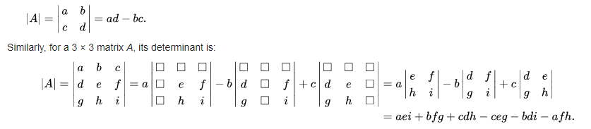

## 3.2 Pandas

Pandas нь өгөгдлийг хадгалах, удирдахад тохиромжтой хоёр өгөгдлийн бүтцээр хангадаг - Series болон DataFrame.  
Series нь нэг хэмжээст массивтай төстэй бол DataFrame нь хүснэгттэй төстэй хүснэгтэн дүрслэл юм.

### 3.2.1 Series

Series объект нь нэг хэмжээст массивын утгуудаас тогтдог бөгөөд элементүүдийг индекс ашиглан лавлаж болно. Series объектыг жагсаалт (list), numpy массив (numpy array) эсвэл Python толь бичгээс (dictionary) үүсгэж болно. Та ихэнх numpy функцуудыг Series объект дээр ашиглаж болно.

```python
from pandas import Series

s = Series([3.1, 2.4, -1.7, 0.2, -2.9, 4.5])   # creating a series from a list
print('Series, s =\n', s, '\n')

print('s.values =', s.values)     # display values of the Series
print('s.index =', s.index)       # display indices of the Series
print('s.dtype =', s.dtype)       # display the element type of the Series
```

```python
import numpy as np

s2 = Series(np.random.randn(6))   # creating a series from a numpy ndarray
print('Series s2 =\n', s2, '\n')
print('s2.values =', s2.values)   # display values of the Series
print('s2.index =', s2.index)     # display indices of the Series
print('s2.dtype =', s2.dtype)     # display the element type of the Series
```

```python
s3 = Series([1.2,2.5,-2.2,3.1,-0.8,-3.2],
            index = ['Jan 1','Jan 2','Jan 3','Jan 4','Jan 5','Jan 6',])

print('Series s3 =\n', s3, '\n')
print('s3.values =', s3.values)   # display values of the Series
print('s3.index =', s3.index)     # display indices of the Series
print('s3.dtype =', s3.dtype)     # display the element type of the Series
```

```python
capitals = {'MI': 'Lansing', 'CA': 'Sacramento', 'TX': 'Austin', 'MN': 'St Paul'}

s4 = Series(capitals)   # creating a series from dictionary object
print('Series s4 =\n', s4, '\n')
print('s4.values =', s4.values)   # display values of the Series
print('s4.index=', s4.index)      # display indices of the Series
print('s4.dtype =', s4.dtype)     # display the element type of the Series
```

```python
s3 = Series([1.2,2.5,-2.2,3.1,-0.8,-3.2],
            index = ['Jan 1','Jan 2','Jan 3','Jan 4','Jan 5','Jan 6',])
print('s3 =\n', s3, '\n')

# Accessing elements of a Series

print('s3[2]=', s3[2])        # display third element of the Series
print('s3[\'Jan 3\']=', s3['Jan 3'])   # indexing element of a Series

print('\ns3[1:3]=')             # display a slice of the Series
print(s3[1:3])
print('\ns3.iloc([1:3])=')      # display a slice of the Series
print(s3.iloc[1:3])
```

Series дахь элементийн тоог олох янз бүрийн функцууд байдаг. Функцийн үр дүн нь null элементүүд агуулагдсан эсэхээс хамаарна.

```python
s3['Jan 7'] = np.nan
print('Series s3 =\n', s3, '\n')

print('Shape of s3 =', s3.shape)   # get the dimension of the Series
print('Size of s3 =', s3.size)     # get the number of elements of the Series
print('Count of s3 =', s3.count()) # get the number of non-null elements of the Series
```

Series элементүүдийг сонгохдоо boolean шүүлтүүрийг ашиглаж болно.

```python
print(s3[s3 > 0])   # applying filter to select non-negative elements of the Series
```

Тоон Series элементүүд дээр скаляр үйлдлүүдийг хийж болно.

```python
print('s3 + 4 =\n', s3 + 4, '\n')
print('s3 / 4 =\n', s3 / 4)
```

Numpy функцүүд нь pandas Series-д ашиглагдаж болно.

```python
print('np.log(s3 + 4) =\n', np.log(s3 + 4), '\n')    # applying log function to a numeric Series
print('np.exp(s3 - 4) =\n', np.exp(s3 - 4), '\n')    # applying exponent function to a numeric Series
```

value_counts() функцийг Series дахь дискрет утга бүрийн тоог хүснэгтэн хэлбэрт эсвэл жагсаалт байдлаар гаргахад ашиглаж болно.

```python
colors = Series(['red', 'blue', 'blue', 'yellow', 'red', 'green', 'blue', np.nan])
print('colors =\n', colors, '\n')

print('colors.value_counts() =\n', colors.value_counts())
```

### 3.2.2 DataFrame

DataFrame объект нь баганын цуглуулгыг агуулсан хүснэгт хэлбэртэй өгөгдлийн бүтэц бөгөөд тэдгээр багана тус бүр нь өөр өөр төрлүүдтэй (numeric, string, boolean гэх мэт) байж болно. Series-с ялгаатай нь DataFrame нь мөр, баганын ялгаатай индекстэй байдаг. DataFrame объектыг үүсгэх олон арга байдаг (жишээлбэл, толь бичиг, tuple-үүдийн жагсаалт, эсвэл бүр numpy-ийн ndarrays гэх мэтээс үүсгэж болно).

```python
from pandas import DataFrame

cars = {'make': ['Ford', 'Honda', 'Toyota', 'Tesla'],
       'model': ['Taurus', 'Accord', 'Camry', 'Model S'],
       'MSRP': [27595, 23570, 23495, 68000]}
carData = DataFrame(cars)            # creating DataFrame from dictionary
carData                              # display the table
```

```python
print('carData.index =', carData.index)         # print the row indices
print('carData.columns =', carData.columns)     # print the column indices
```

Үүсгэчихсэн DataFrame-д багана нэмж байна.

```python
carData2 = DataFrame(cars, index = [1,2,3,4])  # change the row index
carData2['year'] = 2018    # add column with same value
carData2['dealership'] = ['Courtesy Ford','Capital Honda','Spartan Toyota','N/A']
carData2                   # display table
```

tuple-үүдийн жагсаалтаас DataFrame үүсгэж байна.

```python
tuplelist = [(2011,45.1,32.4),(2012,42.4,34.5),(2013,47.2,39.2),
              (2014,44.2,31.4),(2015,39.9,29.8),(2016,41.5,36.7)]
columnNames = ['year','temp','precip']
weatherData = DataFrame(tuplelist, columns=columnNames)
weatherData
```

numpy ndarray-аас DataFrame үүсгэж байна

```python
import numpy as np

npdata = np.random.randn(5,3)  # create a 5 by 3 random matrix
columnNames = ['x1','x2','x3']
data = DataFrame(npdata, columns=columnNames)
data
```

DataFrame объектын элементүүдэд хандах олон арга бий.

```python
# accessing an entire column will return a Series object

print(data['x2'])
print(type(data['x2']))
```

```python
# accessing an entire row will return a Series object

print('Row 3 of data table:')
print(data.iloc[2])       # returns the 3rd row of DataFrame
print(type(data.iloc[2]))

print('\nRow 3 of car data table:')
print(carData2.iloc[2])   # row contains objects of different types
```

```python
# accessing a specific element of the DataFrame

print('carData2 =\n', carData2)

print('\ncarData2.iloc[1,2] =', carData2.iloc[1,2])                # retrieving second row, third column
print('carData2.loc[1,\'model\'] =', carData2.loc[1,'model'])    # retrieving second row, column named 'model'

# accessing a slice of the DataFrame

print('\ncarData2.iloc[1:3,1:3]=')
print(carData2.iloc[1:3,1:3])
```

```python
print('carData2 =\n', carData2, '\n')

print('carData2.shape =', carData2.shape)
print('carData2.size =', carData2.size)
```

```python
# selection and filtering

print('carData2 =\n', carData2, '\n')

print('carData2[carData2.MSRP > 25000] =')
print(carData2[carData2.MSRP > 25000])
```

### 3.2.3 Арифметик үйлдлүүд

```python
print(data)

print('\nData transpose operation: data.T')
print(data.T)    # transpose operation

print('\nAddition: data + 4')
print(data + 4)    # addition operation

print('\nMultiplication: data * 10')
print(data * 10)   # multiplication operation
```

```python
print('data =\n', data)

columnNames = ['x1','x2','x3']
data2 = DataFrame(np.random.randn(5,3), columns=columnNames)
print('\ndata2 =')
print(data2)

print('\ndata + data2 = ')
print(data.add(data2))

print('\ndata * data2 = ')
print(data.mul(data2))
```

```python
print(data.abs())    # get the absolute value for each element

print('\nMaximum value per column:')
print(data.max())    # get maximum value for each column

print('\nMinimum value per row:')
print(data.min(axis=1))    # get minimum value for each row

print('\nSum of values per column:')
print(data.sum())    # get sum of values for each column

print('\nAverage value per row:')
print(data.mean(axis=1))    # get average value for each row

print('\nCalculate max - min per column')
f = lambda x: x.max() - x.min()
print(data.apply(f))

print('\nCalculate max - min per row')
f = lambda x: x.max() - x.min()
print(data.apply(f, axis=1))
```

value_counts() функцийг мөн pandas DataFrame-д хэрэглэж болно.

```python
objects = {'shape': ['circle', 'square', 'square', 'square', 'circle', 'rectangle'],
           'color': ['red', 'red', 'red', 'blue', 'blue', 'blue']}

shapeData = DataFrame(objects)
print('shapeData =\n', shapeData, '\n')

print('shapeData.value_counts() =\n', shapeData['shape'].value_counts().sort_values())
print('shapeData.value_counts() =\n', shapeData['color'].value_counts().sort_values())
```

### 3.2.4 Series and DataFrame-н график дүрслэл

Series эсвэл DataFrame-д хадгалагдсан өгөгдлийн графикийг зурах олон функцууд байдаг.

**(a)** Line plot

```python
%matplotlib inline

s3 = Series([1.2,2.5,-2.2,3.1,-0.8,-3.2,1.4],
            index = ['Jan 1','Jan 2','Jan 3','Jan 4','Jan 5','Jan 6','Jan 7'])
s3.plot(kind='line', title='Line plot')
```

**(b)** Bar plot

```python
s3.plot(kind='bar', title='Bar plot')
```

**(c)** Histogram

```python
s3.plot(kind='hist', title = 'Histogram')
```

**(d)** Box plot

```python
tuplelist = [(2011,45.1,32.4),(2012,42.4,34.5),(2013,47.2,39.2),
              (2014,44.2,31.4),(2015,39.9,29.8),(2016,41.5,36.7)]
columnNames = ['year','temp','precip']
weatherData = DataFrame(tuplelist, columns=columnNames)
print(weatherData)
weatherData[['temp','precip']].plot(kind='box', title='Box plot')
```

**(e)** Scatter plot

```python
print('weatherData =\n', weatherData)

weatherData.plot(kind='scatter', x='temp', y='precip')
```

# Дасгал

**I**. 30-70 хүртэлх бүх тэгш тоонуудыг агуулсан массив үүсгэх NumPy програм бич. Массивын элементүүд болон элементийн тоог хэвлэ.

**II**. Цельсийн градусын утгыг Фаренгейт, мөн эсрэгээр нь буюу Фаренгейтийн градусыг Цельсийн градус болгон хувиргах програм бич. Утгууд нь NumPy массив дээр хадгалагдана. $$ \frac{C}{5} = \frac{F-32}{9} $$

```
Жишээ массив
Фаренгейтийн градусын утгууд: [0, 12, 45.21, 34, 99.91]
Цельсийн градусын утгууд: [-17.78, -11.11, 7.34, 1.11, 37.73, 0. ]
```

**III**. x массивын өгөгдлийг өөрчлөхгүйгээр хэлбэрийг өөрчлөн дараах y болон z массивуудыг үүсгэх NumPy програм бичнэ үү.

```
x = [1 2 3 4 5 6]
y new array 3x2:
[[1 2]
 [3 4]
 [5 6]]
z new array 2x3:
[[1 2 3]
 [4 5 6]]
```

**IV**. Дараах 2 NumPy массив нь тэмдэгтүүд болон түүнд харгалзах кодыг агуулсан байна. Хоёр дахь массиваас 100-с их, 110-с бага кодтой элементүүдэд тохирох тэмдэгтүүдийг хэвлэнэ үү.

```
Жишээ массив:
a = [ 97 101 105 111 117]
b = ['a' 'e' 'i' 'o' 'u']

Output:
e   i
```

**V**. Дараах 2 матрицийн үржвэр матрицийг хэвлэж харна уу. Үүний тулд аль нэг матрицийн хэлбэрийг өөрчилнө үү.

```
a = [[ 1  2  3]
     [ 4  5  6]
     [ 7  8  9]
     [10 11 12]]

b = [[1 2]
     [3 4]
     [5 6]
     [7 8]]
```

**VI**. Өгөгдсөн Series-н өгөгдлийн дундаж ба стандарт хазайлтыг олох Pandas програм бич.

```
[1,2,3,4,5,6,7,8,9,5,3]
```

**VII**. Дараах утгууд бүхий Series-н үг бүрийн эхний ба сүүлийн тэмдэгтийг том болгож, хэвлэж харна уу.

```
'php', 'python', 'java', 'c#'
```

**VIII**. Дараах DataFrame-г үүсгэнэ үү.

a) Эхний 3 мөрийг хэвлэж хар.  
b) name болон score багануудын утгыг хэвлэж хар.  
c) 'name' болон 'score' багана дахь 1, 3, 5, 6 мөрүүдийг хэвлэж хар.  
d) 'attempts' - н утга 2-с их байгаа оюутнуудыг мэдээллийг хэвлэж хар.  
e) 'score'-н утга 15-20 хооронд байгаа оюутнуудын мэдээлийг хэвлэж хар. /Pandas Series: between() function/

```
Dataframe-д агуулагдах утгууд нь:

name:     ['Dorj', 'Khulan', 'Sergelen', 'Ganchimeg', 'Khaliun', 'Bolor', 'Anu', 'Tsetse', 'Purev', 'Zulaa'],
score:    [12.5, 9, 16.5, np.nan, 9, 20, 14.5, np.nan, 8, 19],
attempts: [1, 3, 2, 3, 2, 3, 1, 1, 2, 1],
qualify:  ['yes', 'no', 'yes', 'no', 'no', 'yes', 'yes', 'no', 'no', 'yes']

Индекс нь:

label:    ['a', 'b', 'c', 'd', 'e', 'f', 'g', 'h', 'i', 'j']
```